# EDS212Resources

Adelaide Robinson

2022-08-05

## R Markdown Setup

Add packages in the setup chunk  
the warning chunk sets warnings to not show up in the whole document

# R Markdown notes

adding a line break, two trailing spaces and then hit return

# Github

## setting up a project to be used on github

- in the console type usethis::use_git make sure it is locally controlled
- yes twice it will restart and be committed this is creating a git repository on our computer this still only exists on our computer
- usethis::use_github, saves it on github, should open github

## Adding files to github

make sure you are in the terminal and not the console

- gitadd -A (staging all the files)
- git commit -m “my commit message”
- git push
- git status - check the status

## Adding to gitignore

click on the git ignore file

type nameofdoc.filetype for a specific file

*.filetype for an entire file type

example: eds212.html, *.html

## Working collaboratively in git

### Working without Branches

This workflow is effective if not working on the same files at the same time. Also a good workflow if you are working on different computers.

One person goes onto github and creates a project, and then add collaborators, found under settings, collaborators

Collaborator should get a link, they can then clone the project, create as a project on their computer and then make changes. when done push their changes.Make sure to save before pushing.

The second person should be able to pull git pull and see those changes.

# GGplot

Add the tidyverse package in the setup chunk, and make sure data is available

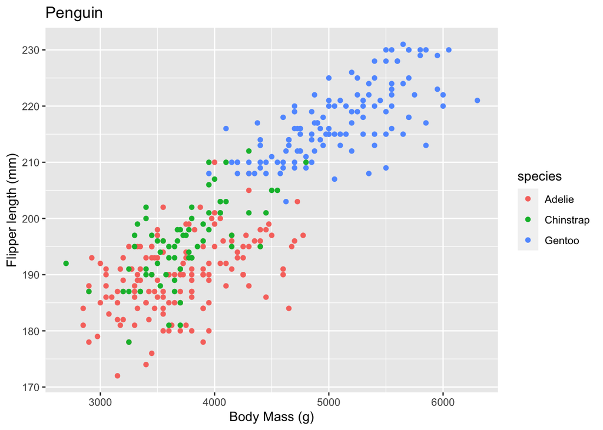

```r
#ggplot(data and mapping, anything to do with variables goes under aes) + type of plot
#basic scatterplot
ggplot(data = penguins, mapping = aes(x = body_mass_g, y = flipper_length_mm)) + geom_point(aes(color = species)) + labs(title = "Penguin", y = "Flipper length (mm)", x = "Body Mass (g)")
```

# Functions

## Basic Function

```r
#first give the variables in the function, then define
standard_weight <- function(a , b, L) {
  a * L^b }

#plug numbers into the function
great_barracuda <- standard_weight(a = 0.0181 , b = 3.27 , L = 60)
great_barracuda
```

```
## [1] 11809.54
```

## Logistic Growth Function

N<sub>t</sub> = k/ 1 + (k - N<sub>0</sub> / N<sub>0</sub>)e<sup>-rt</sup> this function tells you the number of individuals in a population given the initial population, carrying capacity, the time and the rate

```r
#write this equation as a function r can use
#reminder that to use e in r use exp()
pop_logistic <- function(carryingcap, init_pop, rate, time_yr) { carryingcap/ (1 + ((carryingcap - init_pop)/init_pop) * exp(- rate * time_yr))

}
#plug in given numbers to find exact population at a given time
pop_logistic(carryingcap = 2580, init_pop = 230, rate = 0.32, time_yr = 2.4)
```

```
## [1] 449.4572
```

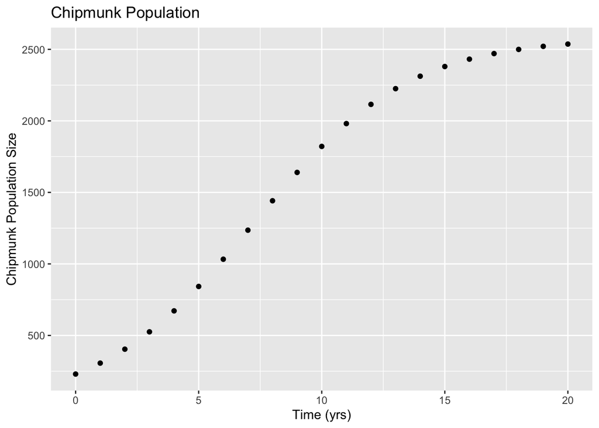

```r
# or create a sequence and show it over time
time_seq <- seq( from = 0, to = 20, by = 1)
#and then plug it in
chipmunk_pop <- pop_logistic(carryingcap = 2580, init_pop = 230, rate = 0.32, time_yr = time_seq)
#make this into a dataframe to graph
chip_dataframe <- data_frame(time_seq, chipmunk_pop)
#then graph
ggplot(data = chip_dataframe, aes(x = time_seq , y = chipmunk_pop)) + geom_point() + labs( title = "Chipmunk Population", x = "Time (yrs)", y = "Chipmunk Population Size")
```

## Solving the function for a sequence

```r
# make a vector with possible fish lengths, use the seq function and from, to and by
barracuda_length <- seq(from = 0 , to = 200 , by = 1)
#estimate weights using this vector
#plugging in known values for a and b
barracuda_weight <- standard_weight( a = 0.0181, b = 3.27 , L = barracuda_length)
#make these two vectors into a dataframe
barracuda_dataframe <- data.frame(x = barracuda_length , y = barracuda_weight)
```

# Derivatives

Taking the derivative for an expression

```r
#define the expression
func1 <- expression(5 * x ^ 2)
#take the derivative, define the variable which you are taking the derivative in respect to
my_deriv <- deriv(func1, "x")
my_deriv
```

```
## expression({
##     .value <- 5 * x^2
##     .grad <- array(0, c(length(.value), 1L), list(NULL, c("x")))
##     .grad[, "x"] <- 5 * (2 * x)
##     attr(.value, "gradient") <- .grad
##     .value
## })
```

```r
#define x to solve for a specific number
#second number is the answer
x <- 1
eval(my_deriv)
```

```
## [1] 5
## attr(,"gradient")
##       x
## [1,] 10
```

another option, gives simpler output

Find the slope of $g(z) = 2 z^3 -10.5z^2 +4.1$

```r
func2 <- expression(2 * z ^ 3 -10.5 *z ^2 +4.1)
your_deriv <- D(func2, "z")
your_deriv
```

```
## 2 * (3 * z^2) - 10.5 * (2 * z)
```

```r
#find derivative over a sequence of values
z <- seq(from = 0, to = 5, by = 0.5)
eval(your_deriv)
```

```
##  [1]   0  -9 -15 -18 -18 -15  -9   0  12  27  45
```

## Lotka-Volterra Example and Using the ODE function

As described in the lecture, the Lotke-Volterra models have been used to describe predator-prey populations.

#### Prey equation:

$$\frac{dx}{dt}=\alpha x-\beta
xy$$

From Wikipedia: “The prey are assumed to have an unlimited food supply and to reproduce exponentially, unless subject to predation; this exponential growth is represented in the equation above by the term $\alpha x$. The rate of predation upon the prey is assumed to be proportional to the rate at which the predators and the prey meet, this is represented above by

$\beta xy$. If either x or y is zero, then there can be no predation.”

$$\frac{dy}{dt}=\delta xy - \gamma
y$$

From Wikipedia: “In this equation, $\delta xy$ represents the growth of the predator population. (Note the similarity to the predation rate; however, a different constant is used, as the rate at which the predator population grows is not necessarily equal to the rate at which it consumes the prey). The term $\gamma y$ represents the loss rate of the predators due to either natural death or emigration, it leads to an exponential decay in the absence of prey.

Where:

- $x$ is prey population (e.g. rabbits)

- $y$ is predator population (e.g. wolves)

- $\alpha, \beta, \gamma, \delta$ are positive parameters

Solving the Lotke-Volterra equation:

```r
# Create a sequence of times (days):
time <- seq(0, 25, by = 0.05)

# Set some parameter values (these can change - keep it in mind):
parameters <- c(alpha = .85, beta = 0.8, delta = 0.5, gamma = 1)

# Set the initial condition (prey and predator populations at t = 0).
# Recall: x = prey, y = predator
init_cond <- c(x = 5, y = 3)

# Prepare the series of differential equations as a function:
lk_equations <- function(time, init_cond, parameters) {
  with(as.list(c(init_cond, parameters)), {
    dxdt = alpha * x - beta * x * y
    dydt = delta * x * y - gamma * y
    return(list(c(dxdt, dydt)))
  })
}

# Find the approximate the solution using `deSolve::ode()`:
approx_lk <- ode(y = init_cond, times = time, func = lk_equations, parms = parameters)

# Check the class:
class(approx_lk)
```

```
## [1] "deSolve" "matrix"
```

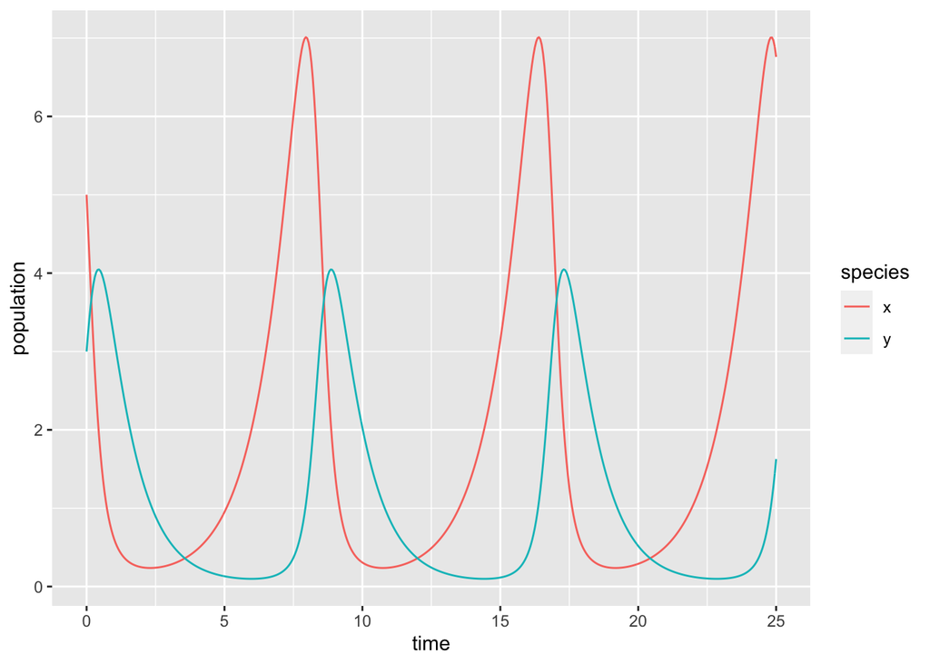

```r
# We really want this to be a data frame, and we want both prey (x) and predator (y) to be in the same column -- we'll learn why in EDS 221 (tidy data)
approx_lk_df <- data.frame(approx_lk) %>%
  pivot_longer(cols = c(x,y), names_to = "species", values_to = "population")

# Plot it!
ggplot(data = approx_lk_df, aes(x = time, y = population)) +
  geom_line(aes(color = species))
```

# Vectors, Matrices and dot product

## making vectors

```r
marmots <- c("blue", "green", 4, "yellow")

#Check the class

class(marmots)
```

```
## [1] "character"
```

```r
pika <- c(12.4, 6.8, 2.9, 8.8, 8.5)

class(pika)
```

```
## [1] "numeric"
```

```r
#scalar multiplier

scalar_pika <- 5.2 * pika

scalar_pika
```

```
## [1] 64.48 35.36 15.08 45.76 44.20
```

```r
#you can also add or subtract vectors ( as long as they are the same length)
ferret <- c(1, 12, 18, 2, 8)

pika - ferret
```

```
## [1]  11.4  -5.2 -15.1   6.8   0.5
```

The dot product is the sum of elements of each vector multiplied together, and is a measure of how close the vectors “point” in the same direction

```r
pika %*% ferret
```

```
##       [,1]
## [1,] 231.8
```

[output not shown]

[output not shown]

```r
class(my_matrix)
```

```
## [1] "matrix" "array"
```